# Deep Learning — Assignment 10 — Score sheet

Tenth assignment for the 2024 Deep Learning course (NWI-IMC070) of the Radboud University.

Please enter your names and group number.**Names:**

**Group:**

## Objectives

In this assignment you will

1. Implement the components of a normalizing flow model.
2. Train a normalizing flow on a simple dataset.
3. Compare normalizing flows to other models.

## Required software

As before you will need these libraries:

- `torch`
- `sklearn`

All libraries can be installed with `pip install`.

```python
%config InlineBackend.figure_formats = ['png']
%matplotlib inline

import itertools
import numpy as np
import matplotlib.pyplot as plt
import torch
import torch.distributions.distribution
from torch.distributions import Distribution, Normal, MultivariateNormal
import sklearn.datasets

# Fix the seed to make the solutions more reproducible
torch.manual_seed(12345);

# Use the GPU if available
def detect_device():
    if torch.cuda.is_available():
        return torch.device("cuda")
    elif torch.backends.mps.is_available():
        return torch.device("mps")
    else:
        return torch.device("cpu")
device = detect_device()
```

## 10.1 Invertible transformations (5 points)

A normalizing flow model is built out of invertible functions. We can implement these as a module that not only has a `forward` function, but also an `inverse`.

In addition to computing the function $z = f(x)$, we will also need to know the (log) determinant of the Jacobian, that is $\det(\partial f(z) / \partial z)$. While we could use automatic differentiation to compute the Jacobian, that is very expensive, and we would then still need to compute the determinant, and we also need gradients of this log determinant. So instead, we will make our layers return a tuple of the new value and the log determinant. We will have a closer look at what this means in the next section.

```python
class FlowLayer(torch.nn.Module):
    def forward(self, z):
        """
        Apply a transformation to z_1, and compute log determinant of the Jacobian.
        z can be a tensor or a tuple of tensors.
        Return z_2, log det(∂z_2/∂z_1)
        """
        raise NotImplementedError("Forward function not implemented")

    def inverse(self, z):
        """
        Transformation that is the inverse of self.forward()
        Return z_1, log det(∂z_1/∂z_2)
        """
        raise NotImplementedError("Inverse function not implemented")
```

A nice aspect of these FlowLayers is that we can test if they are implemented correctly by checking that `layer.inverse(layer.forward(x)[0])[0] == x`. Below is a function that tests that a flow layer is implemented correctly by checking this and other properties. You do not have to understand all the details.

```python
def isclose(a,b):
    """
    Returns True if two tensors or tuples of tensors are equal or close to equal.
    """
    if isinstance(a, tuple):
        return len(a) == len(b) and all([isclose(c,d) for c,d in zip(a,b)])
    elif isinstance(a, int) or isinstance(a, float):
        return isclose(torch.tensor(a), torch.tensor(b))
    else:
        return torch.isclose(a, b, atol=1e-6).all()

def num_samples(a):
    """
    Return the number of samples in a tensor or in a tuple of tensors.
    """
    if isinstance(a, tuple):
        return num_samples(a[0])
    else:
        return len(a)

def log_det_jacobian(layer, a, *args):
    """
    Compute logdet of the Jacobian using automatic differentiation.
    """
    if isinstance(a, tuple):
        j = torch.autograd.functional.jacobian(lambda *a: layer.forward(a, *args)[0], a)
    else:
        j = torch.autograd.functional.jacobian(lambda a: layer.forward(a, *args)[0], a)
    out = torch.zeros(num_samples(a))
    for i in range(num_samples(a)):
        if isinstance(j, torch.Tensor):
            ji = j[i,:,i,:]
        elif isinstance(j[0], torch.Tensor):
            if isinstance(a, tuple):
                ji = torch.cat([r[i,:,i,:] for r in j], dim=1)
            else:
                ji = torch.cat([r[i,:,i,:] for r in j], dim=0)
        else:
            ji = torch.cat([torch.cat([c[i,:,i,:] for c in r], dim=1) for r in j], dim=0)
        out[i] = torch.logdet(ji)
    return out

def scalar_to_vector(x, n):
    if not isinstance(x, torch.Tensor):
        return torch.tensor(x, dtype=torch.float).repeat(n)
    elif x.shape == torch.Size():
        return x.repeat(n)
    else:
        return x

def test_flow_layer(layer, z, *args):
    """
    Verify that a layer's forward() and inverse() functions are inverses of each other,
    and that the log determinant is sensible.
    """
    z2, log_det_forward = layer.forward(z, *args)
    z3, log_det_inverse = layer.inverse(z2, *args)
    log_det_forward = scalar_to_vector(log_det_forward, num_samples(z))
    log_det_inverse = scalar_to_vector(log_det_inverse, num_samples(z))
    assert num_samples(z2) == num_samples(z), \
            "Layer's output should have same number of samples as the input."
    assert isclose(z3, z), \
            "Layer's `inverse` function should be the inverse of `forward`."
    assert isinstance(log_det_forward, torch.Tensor) and log_det_forward.shape == torch.Size([num_samples(z)]), \
            "Log determinant of Jacobian should be a tensor with one element per sample (hint: `num_samples` gives the number of samples)."
    assert isclose(log_det_forward, -log_det_inverse), \
            "Log determinant of Jacobian for inverse should be negative of log determinant of Jacobian of forward."
    assert isclose(log_det_forward, log_det_jacobian(layer, z, *args)), \
            "Log determinant returned by `forward` should match that computed using `log_det_jacobian`"
```

### How transformations affects probability density

Suppose that we have $z \sim U(0,1)^2$, that is, $z$ has a two dimensional uniform distribution. Now scale the values by a factor $2$, $z_2 = 2z$.

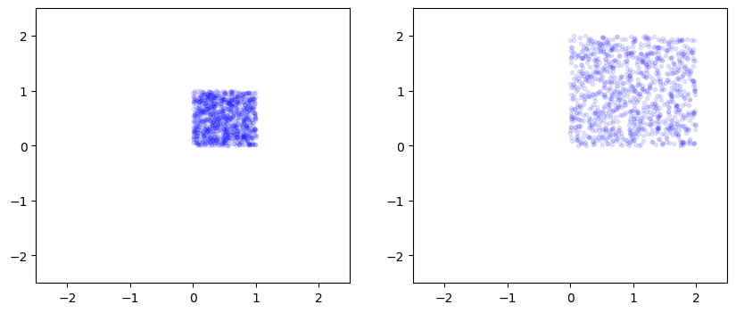

```python
z = torch.rand(1000,2)
z2 = 2 * z

plt.figure(figsize=(10, 4))
plt.subplot(1, 2, 1)
plt.plot(z[:,0], z[:,1], 'b.', alpha=0.1);
plt.xlim(-2.5, 2.5)
plt.ylim(-2.5, 2.5)
plt.subplot(1, 2, 2)
plt.plot(z2[:,0], z2[:,1], 'b.', alpha=0.1);
plt.xlim(-2.5, 2.5)
plt.ylim(-2.5, 2.5);
```

**10.1 a Add comment(a) How does scaling affect the area of the square? And how does it affect the probability density inside the square? (1 point)**

Answer:

The area is scaled by 2^2, the probability density is scaled inversely, so by 1/2^2.

*Grading:*

- 0.5 points for the scaling of the area
- 0.5 points for the scaling of the probability density

**10.1 b Add comment(b) If we scale one dimension by a factor 2, and another by a factor 0.5, how does this affect the area and the probability density? (1 point)**

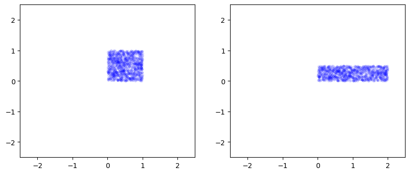

```python
### BEGIN ANSWER
z = torch.rand(1000,2)
z2 = z * torch.tensor([2,0.5])[None]

plt.figure(figsize=(10, 4))
plt.subplot(1, 2, 1)
plt.plot(z[:,0], z[:,1], 'b.', alpha=0.1);
plt.xlim(-2.5, 2.5)
plt.ylim(-2.5, 2.5)
plt.subplot(1, 2, 2)
plt.plot(z2[:,0], z2[:,1], 'b.', alpha=0.1);
plt.xlim(-2.5, 2.5)
plt.ylim(-2.5, 2.5);
### END ANSWER
```

Answer:

2 * 0.5 = 1, so both area and probability density stay the same.

*Grading:*

- 1 point for a correct answer.

The determinant of the Jacobian corresponds to the scale factor of the area. The log determinant of the Jacobian is of course the log of this scale factor.

**10.1 c Add comment(c) Use this knowledge to implement an invertible function that scales the input by a scale factor for each dimension. (1 point)**

```python
class Scale(FlowLayer):
    def __init__(self, scale):
        self.scale = scale

    def forward(self, z):
        ### BEGIN ANSWER
        return z * self.scale[None,:], torch.sum(torch.log(self.scale))
        ### END ANSWER

    def inverse(self, z):
        ### BEGIN ANSWER
        return z / self.scale[None,:], -torch.sum(torch.log(self.scale))
        ### END ANSWER
```

**(d) Test your implementation. (no points)**

```python
layer = Scale(torch.tensor([2,2]))
test_flow_layer(layer, torch.randn(10,2))
```

**10.1 e Add comment(e) If we translate the points by adding a constant, how does this affect the area and probability distribution? (1 point)**

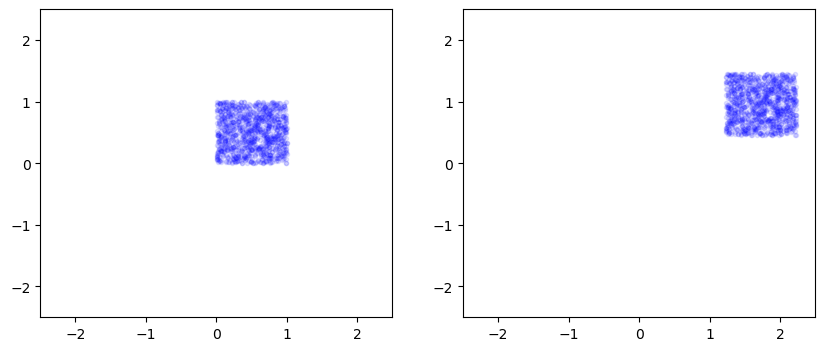

```python
### BEGIN ANSWER
z = torch.rand(1000,2)
z2 = z + torch.tensor([1.23,0.456])[None]

plt.figure(figsize=(10, 4))
plt.subplot(1, 2, 1)
plt.plot(z[:,0], z[:,1], 'b.', alpha=0.1);
plt.xlim(-2.5, 2.5)
plt.ylim(-2.5, 2.5)
plt.subplot(1, 2, 2)
plt.plot(z2[:,0], z2[:,1], 'b.', alpha=0.1);
plt.xlim(-2.5, 2.5)
plt.ylim(-2.5, 2.5);
### END ANSWER
```

Answer:

Translation does not affect the area or the probability density inside the square.

*Grading:*

- 1 point for a correct answer.

**10.1 f Add comment(f) Use this knowledge to implement an invertible function that translates the input by a fixed offset. (1 point)**

```python
class Translate(FlowLayer):
    def __init__(self, offset):
        self.offset = offset

    def forward(self, z):
        ### BEGIN ANSWER
        return z + self.offset[None,:], 0
        ### END ANSWER

    def inverse(self, z):
        ### BEGIN ANSWER
        return z - self.offset[None,:], 0
        ### END ANSWER
```

**(g) Test your implementation. (no pointss)**

```python
layer = Translate(torch.tensor([2,2]))
test_flow_layer(layer, torch.randn(10,2))
```

## 10.2 Invertible transformations for RealNVP (10 points)

In this section we will build all the invertible transformations that we need to implement the RealNVP normalizing flow model.

### Affine coupling

The main ingredient of our normalizing flow model is going to be the *affine coupling layer*. This layer takes an input that is split in two parts ($z_A$ and $z_B$), and applies an affine tranformation to $z_B$ using parameters that come from a neural network block applied on $z_A$.

In other words: $$z_B' = \exp(s) z_B + t$$ where $$s,t = f(z_A)$$

We will handle the splitting of a single tensor into two later. For this layer, the input and output will be a tuple of tensors.

**10.2 a Add comment(a) Complete the implementation below. (3 points)**

Hint: To get two values from the neural network block $f(z_A)$ (`block` in the code below), you can use `torch.chunk`, which splits a single tensor along a given dimension into a tuple of tensors.

*Grading:*

- 1 point for the forward function
- 1 point for the inverse function
- 1 point for correct log_dets
- max 1 point if the test fails

```python
class AffineCoupling(FlowLayer):
    def __init__(self, block):
        super().__init__()
        self.block = block

    def forward(self, z):
        zA, zB = z
        ### BEGIN ANSWER
        st = self.block(zA)
        s, t = torch.chunk(st, 2, dim=-1)
        zB = zB * torch.exp(s) + t
        log_det = torch.sum(s, dim=-1)
        ### END ANSWER
        return (zA, zB), log_det

    def inverse(self, z):
        zA, zB = z
        ### BEGIN ANSWER
        st = self.block(zA)
        s, t = torch.chunk(st, 2, dim=-1)
        zB = (zB - t) * torch.exp(-s)
        log_det = -torch.sum(s, dim=-1)
        ### END ANSWER
        return (zA, zB), log_det
```

For the neural network blocks in the coupling layers, we will use simple MLPs with two hidden layers and ReLU activation functions.

**10.2 b Add comment(b) Complete the implementation of `block` below. (1 point)**

Note: the output will be split into $s$ and $t$ by the AffineCoupling layer, both of which have `dim_B` columns.

*Grading:*

- 1 point for a correct implementation.
- -0.5 points for using a different number of layers.

```python
def block(dim_A, dim_B, dim_hidden):
    """
    Create a neural network block for use in an `AffineCoupling` layer.
    Parameters:
      dim_A: the dimensionality of z_A
      dim_B: the dimensionality of z_B
      dim_hidden: the dimensionality of the hidden layers
    """
    ### BEGIN ANSWER
    return torch.nn.Sequential(
        torch.nn.Linear(dim_A, dim_hidden),
        torch.nn.ReLU(),
        torch.nn.Linear(dim_hidden, dim_hidden),
        torch.nn.ReLU(),
        torch.nn.Linear(dim_hidden, dim_B * 2),
    )
    ### END ANSWER
```

**(c) Use the code below to verify that your implementation is correct. (no points)**

```python
# Verify the implementation of the AffineCoupling layer.
layer = AffineCoupling(block(5, 4, 12))
z = (torch.randn(3, 5), torch.randn(3, 4))
test_flow_layer(layer, z)
assert not isclose(layer.forward(z)[0], z), "The layer should not be trivial"
```

**10.2 d Add comment(d) If we apply two AffineCoupling functions after eachother, does this give a more powerful or flexible function compared to a single AffineCoupling layer? Explain your answer. (1 point)**

Answer:

Both coupling layers apply a linear transformation to zB based on zA. And zA does not change. The composition of two linear transformations is still a linear transformation. So this is not more flexible.

There might be a slight indcrease in flexibility if you consider using the same neural network to compute the transformations, but an equivalent result can be had by using more hidden layers.

*Grading:*

- 1 point for observing that multiple linear transformations are not more flexible.

### Plumbing

Before we can actually use the affine coupling layer, we will need to do some plumbing.

The affine coupling layers we just defined above needs the input to be split into two parts (called $z_A$ and $z_B$ in the book). We can implement this splitting as a separate flow layer, because the splitting by itself is also an invertible transformation.

**10.2 e Add comment(e) Complete the implementation of `Split` below. (1 point)**

To split a tensor you can use `torch.chunk`, which returns a tuple of tensors. To combine tensors you can use `torch.cat`.

```python
class Split(FlowLayer):
    def forward(self, z):
        ### BEGIN ANSWER
        return torch.chunk(z, 2, dim=-1), 0
        ### END ANSWER
    def inverse(self, z):
        ### BEGIN ANSWER
        return torch.cat(z, dim=-1), 0
        ### END ANSWER

class Merge(FlowLayer):
    def forward(self, z):
        return Split().inverse(z)
    def inverse(self, z):
        return Split().forward(z)

assert isinstance(Split().forward(torch.randn(3, 9)), tuple), "Split should produce a tuple: split_z, log_det"
assert isinstance(Split().forward(torch.randn(3, 9))[0], tuple), "Split should produce a tuple"
assert isinstance(Split().inverse((torch.randn(3, 5), torch.randn(3, 4)))[0], torch.Tensor), "Split's inverse should produce a tensor"
test_flow_layer(Split(), torch.randn(3, 9))
test_flow_layer(Merge(), (torch.randn(3, 5), torch.randn(3, 4)))
```

The affine coupling layer always operates on the second part of the tuple, $z_B$. A simple way to also change $z_A$ is to swap the elements in the tuple.

**10.2 f Add comment(f) Implement a layer that swaps the two elements of a tuple. (1 point)**

*Grading:*

- 1 point for a correct implementation that passes the tests.

```python
class Swap(FlowLayer):
    ### BEGIN ANSWER
    def forward(self, z):
        return (z[1], z[0]), 0
    def inverse(self, z):
        return (z[1], z[0]), 0
    ### END ANSWER

z = (torch.randn(3, 5), torch.randn(3, 4))
test_flow_layer(Swap(), z)
z = (torch.randn(3, 5), torch.randn(3, 5))
assert not isclose(Swap().forward(z)[0], z), "The layer should not be trivial"
```

### Sequential composition

The composition of multiple invertible functions is still an invertible function. Normaly when composing multiple layers in sequence you would use `torch.nn.Sequential`. But that does not work for our `FlowLayer`s. Instead we can make our own class for sequential composition.

**10.2 g Add comment(g) Complete the implementation below. (2 points)**

*Grading:*

- 1 point for computing z in the forward and inverse directions
- 1 point for computing log_det in the forward and inverse directions
- no points if the tests do not pass

```python
class SequentialFlow(FlowLayer):
    def __init__(self, *layers):
        super().__init__()
        self.layers = torch.nn.ModuleList(layers)

    def forward(self, z):
        ### BEGIN ANSWER
        total_log_det = 0
        for layer in self.layers:
            z, log_det = layer.forward(z)
            total_log_det += log_det
        return z, total_log_det
        ### END ANSWER

    def inverse(self, z):
        ### BEGIN ANSWER
        total_log_det = 0
        for layer in reversed(self.layers):
            z, log_det = layer.inverse(z)
            total_log_det += log_det
        return z, total_log_det
        ### END ANSWER
```

**10.2 h Add comment(h) Verify the implementation of `SequentialFlow`. (1 point)**

Make sure to use multiple non-trivial layers to ensure that the composition works correctly.

*Grading:*

- 1 point for composing multiple non-trivial layers in the verification. The answer should use at least two AffineCoupling layers.

```python
# Verify the implementation
layer = SequentialFlow(
    ### BEGIN ANSWER
    AffineCoupling(block(5, 5, 12)),
    Swap(),
    AffineCoupling(block(5, 5, 13)),
    Swap(),
    AffineCoupling(block(5, 5, 14)),
    ### END ANSWER
)
### BEGIN ANSWER
z = (torch.randn(3, 5), torch.randn(3, 5))
### END ANSWER
test_flow_layer(layer, z)
```

## 10.3 Distributions (3 points)

The other ingredient in a normalizing flow model is a base distribution. To sample from a normalizing flow, draw $z \sim p_\text{base}$, and tranform it with an invertible $f_\text{flow}$.

Fortunately for us, common probability distributions are already implemented in `torch.distributions`.

Unfortunately, these are mostly univariate distributions. What we need are distributions over vectors. For this we can use a simple adapter class.

**10.3 a Add comment(a) Complete the code below. (1 points)**

```python
class Multivariate:
    def __init__(self, width, dist=Normal(0,1)):
        self.width = width
        self.dist = dist

    def sample(self, n=1):
        """Draw n samples from this distribution."""
        ### BEGIN ANSWER
        return self.dist.sample((n, self.width))
        ### END ANSWER

    def log_prob(self, x):
        """Compute the log probability of each sample in x."""
        ### BEGIN ANSWER
        return torch.sum(self.dist.log_prob(x), dim=1)
        ### END ANSWER

dist = Multivariate(2)
assert dist.sample(10).shape == torch.Size((10, 2))
assert dist.log_prob(torch.randn(10,2)).shape == torch.Size((10,))
assert dist.log_prob(torch.zeros(1,2))[0] == -torch.log(torch.tensor(2 * torch.pi))
```

**(b) Use the following code to plot the density and some samples from this distribution. (no points)**

```python
def plot_log_prob(model, xmin=-2.5, xmax=2.5, steps=500, min_prob=-10, colorbar=True):
    with torch.no_grad():
        x0, x1 = torch.meshgrid(torch.linspace(xmin, xmax, steps=steps),
                                torch.linspace(xmin, xmax, steps=steps), indexing='ij')
        x = torch.stack([x0.flatten(), x1.flatten()], axis=1).to(device)
        y = model.log_prob(x).cpu().numpy()
        y = y.reshape(x0.shape)
        y[y < min_prob] = min_prob - 1
        plt.contourf(x0, x1, y)
        if colorbar:
            plt.colorbar()

def plot_samples(model, n = 10000, xmin=-2.5, xmax=2.5):
    with torch.no_grad():
        if isinstance(model, Distribution):
            samples = model.sample([n]).cpu()
        else:
            samples = model.sample(n).cpu()
        plt.plot(samples[:, 0], samples[:, 1], 'b.', alpha=0.1)
        plt.xlim(xmin, xmax)
        plt.ylim(xmin, xmax)

def plot_log_prob_and_samples(model, n = 10000, xmin=-2.5, xmax=2.5, steps=500, min_prob=-10):
    plt.figure(figsize=(12, 4))
    plt.subplot(1, 2, 1)
    plot_log_prob(model, xmin, xmax, steps, min_prob)
    plt.subplot(1, 2, 2)
    plot_samples(model, n, xmin, xmax)
```

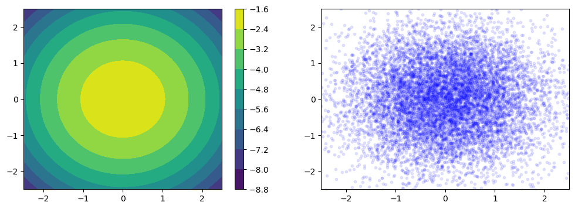

```python
dist = Multivariate(2, Normal(0,1))
plot_log_prob_and_samples(dist)
```

### Normalizing flows as distributions

A normalizing flow model also gives a probability distribution. So we can implement the same functions `sample` and `log_prob`.

To sample, take a sample from the base distribution and apply a transformation.

To compute the log probability, apply the inverse transformation, and compensate for the change in area.

**10.3 c Add comment(c) Complete the code below. (2 points)**

*Grading:*

- 1 point for `sample`.
- 1 point for `log_prob`.

```python
class NormalizingFlow(torch.nn.Module):
    def __init__(self, base_distribution, *layers):
        super().__init__()
        self.base_distribution = base_distribution
        self.flow = SequentialFlow(*layers)

    def sample(self, n=1):
        """Draw n samples from this distribution."""
        ### BEGIN ANSWER
        z = self.base_distribution.sample(n)
        return self.flow.forward(z)[0]
        ### END ANSWER

    def log_prob(self, x):
        """Compute the log probability of each sample in x."""
        ### BEGIN ANSWER
        z, log_det = self.flow.inverse(x)
        base_log_prob = self.base_distribution.log_prob(z)
        return base_log_prob + log_det
        ### END ANSWER
```

**(d) As a simple test, we can visualize a normalizing flow with fixed layers. (no points)**

This distribution should be identical to a multivariate normal distribution.

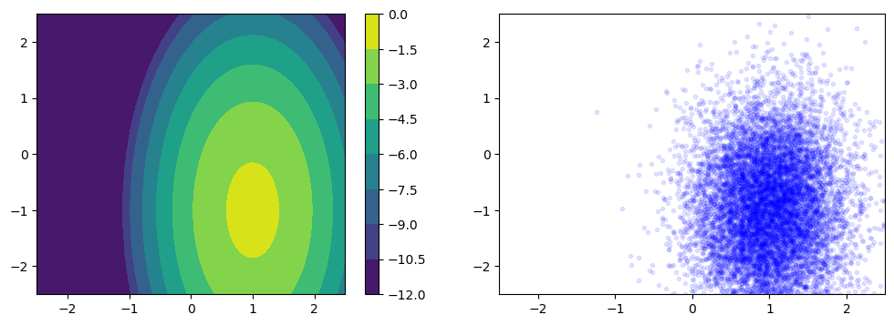

```python
dist = NormalizingFlow(
    Multivariate(2, Normal(0,1)),
    Scale(torch.tensor([0.5,1])),
    Translate(torch.tensor([1,-1]))
)
plot_log_prob_and_samples(dist)
```

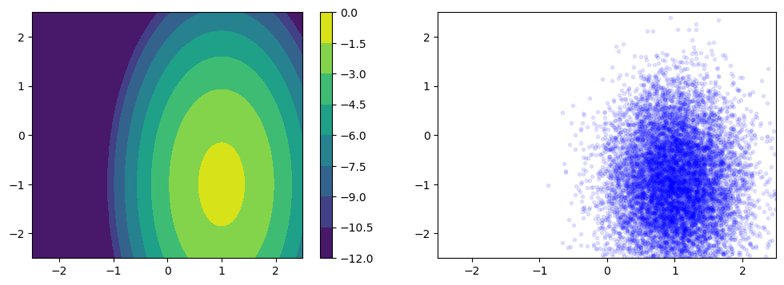

```python
dist = MultivariateNormal(torch.tensor([1.0,-1.0]), torch.diag(torch.tensor([0.5,1.0]) ** 2))
plot_log_prob_and_samples(dist)
```

## 10.4 Training (2 points)

To train a normalizing flow model, we can maximize the log likelihood of the data, or equivalently minimize the negative log likelihood.

**10.4 a Add comment(a) Implement the `train` function. (2 points)**

Assume that the data set contains `x,y` pairs, and ignore `y`.

*Grading:*

- 1 point for using the correct loss function.
- 1 point for a good training loop.

```python
### BEGIN ANSWER
class Metrics:
    """Accumulate mean values of one or more metrics."""
    def __init__(self, n):
        self.count = 0
        self.sum = (0,) * n
    def add(self, count, *values):
        self.count += count
        self.sum = tuple(s + count * v for s,v in zip(self.sum,values))
    def mean(self):
        return tuple(s / self.count for s in self.sum)
### END ANSWER
```

```python
def train(model, data_loader, num_epochs=100, lr=0.001, optimizer=torch.optim.Adam, device=device):
    """
    Train a normalizing flow model on the given data set.
    """
    ### BEGIN ANSWER
    model.to(device)
    optimizer = optimizer(model.parameters(), lr=lr)

    for epoch in range(num_epochs):
        # Sum of training loss, sum of training accuracy, no. of examples
        model.train()
        metrics = Metrics(1)
        for x, _ in data_loader:
            optimizer.zero_grad()
            x = x.to(device)
            loss = -torch.mean(model.log_prob(x))
            loss.backward()
            optimizer.step()
            with torch.no_grad():
                metrics.add(len(x), loss.item())

        # Update plotter
        train_loss, = metrics.mean()
        #plotter.add(epoch + 1, (train_loss,))
        print(train_loss)

    train_loss, = metrics.mean()
    #train_time = time.time() - start_time
    print(f'train loss {train_loss:.3f}')
    #print(f'{metrics.count * num_epochs / train_time:.1f} examples/sec '
    #      f'on {str(device)}')
    ### END ANSWER
```

## 10.5 Two moons dataset (6 points)

In this assignment we will once again use the noisy two moons dataset.

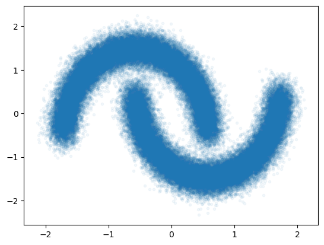

```python
n_samples = 100000
noisy_moons = sklearn.datasets.make_moons(n_samples=n_samples, noise=.1)
noisy_moons[0][:, 0] -= np.mean(noisy_moons[0][:, 0])
noisy_moons[0][:, 0] /= np.std(noisy_moons[0][:, 0])
noisy_moons[0][:, 1] -= np.mean(noisy_moons[0][:, 1])
noisy_moons[0][:, 1] /= np.std(noisy_moons[0][:, 1])
plt.plot(noisy_moons[0][:, 0], noisy_moons[0][:, 1], '.', alpha=0.05);
```

```python
noisy_moons_points = torch.tensor(noisy_moons[0], dtype=torch.float32)
noisy_moons_labels = torch.tensor(noisy_moons[1])
moon_dataset = torch.utils.data.TensorDataset(noisy_moons_points, noisy_moons_labels)
moon_data_loader = torch.utils.data.DataLoader(moon_dataset, batch_size=128)
```

**10.5 a Add comment(a) Create a normalizing flow model. (1 point)**

The model should have 4 affine coupling layers. The neural network block should use a hidden dimension of 16. Use a standard normal distribution as the base distribution.

*Grading:*

- 1 point for the correct network.

```python
### BEGIN ANSWER
dim_hidden = 16
model = NormalizingFlow(
    Multivariate(2),
    Split(),
    AffineCoupling(block(1, 1, dim_hidden)),
    Swap(),
    AffineCoupling(block(1, 1, dim_hidden)),
    Swap(),
    AffineCoupling(block(1, 1, dim_hidden)),
    Swap(),
    AffineCoupling(block(1, 1, dim_hidden)),
    Merge(),
).to(device)

# Or we could use a more generic function
def make_model(num_layers, dim_in, dim_hidden):
    base = Multivariate(dim_in)
    layers = []
    layers.append(Split())
    for _ in range(num_layers):
        layers.append(Swap())
        layers.append(AffineCoupling(block(dim_in // 2, dim_in // 2, dim_hidden)))
    layers.append(Merge())
    return NormalizingFlow(base, *layers)

model = make_model(4, 2, 16)
### END ANSWER
```

**10.5 b Add comment(b) Train the normalizing flow model. (1 points)**

Hint: the negative log probability per sample of the data after training should be < 1.9.

*Grading:*

- 1 point for a correct call, with a loss < 1.9 and > 1.5.

```python
### BEGIN ANSWER
train(model, moon_data_loader, num_epochs=20)
### END ANSWER
```

```
2.4054788671875
2.2064348066711426
2.15370821105957
2.0513225160980224
2.003263055000305
1.9725643055725097
1.9471523799133301
1.9334010999298095
1.9243807886505127
1.9153785622024535
1.9108852505111695
1.9054051877212523
1.9031712100982665
1.9014415421676636
1.9007087716674804
1.9001190353393556
1.9101587727355958
1.8985401226425171
1.897060193901062
1.8966270679855346
train loss 1.897
```

**(c) Plot the distribution of the trained model. (no points)**

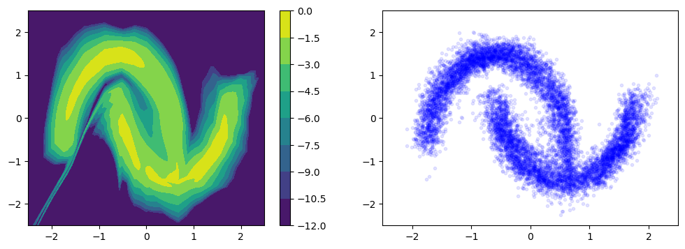

```python
plot_log_prob_and_samples(model)
```

**(d) Plot the distribution of the trained model on top of the data. (no points)**

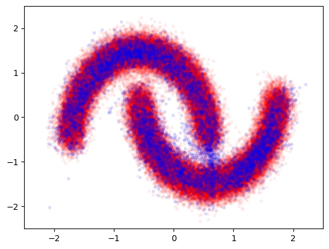

```python
plt.plot(noisy_moons[0][:, 0], noisy_moons[0][:, 1], 'r.', alpha=0.05)
plot_samples(model)
```

**10.5 e Add comment(e) If you look closely, there is a region connecting the two moons that has a non-zero probability according to the model, which is not in the training data. Can you explain why this happens? (1 point)**

Note: Where these regions occur depends on the initialization of the model. These regions become smaller with more training.

Answer:

This happens because the transformation is continuous, and the base distribution is connected. We are only stretching space, so the distribution remains connected.

*Grading:*

- 1 point for the correct answer.

Instead of transforming points from the base distribution to the target distribution, we can use the inverse transformation of `model.flow` to tranform points back from the target distribution.

**10.5 f Add comment(f) Transform the points in the dataset with this inverse tranformation, and plot them. (1 point)**

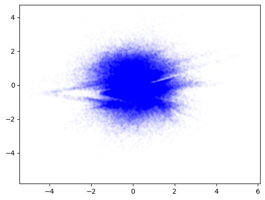

```python
def plot_inverse_samples(model, data):
    ### BEGIN ANSWER
    with torch.no_grad():
        z = model.flow.inverse(data)[0]
        plt.plot(z[:, 0], z[:, 1], 'b.', alpha=0.01);
    ### END ANSWER

plot_inverse_samples(model, noisy_moons_points)
```

**10.5 g Add comment(g) What distribution do you expect for the inversely transformed training data? And does the plot match your expectations? (1 point)**

Answer:

You would expect a standard normal distribution.

The points are close to that, but it does not match exactly.

*Grading:*

- 0.5 points for standard normal distribution
- 0.5 points for mentioning that there are differences.

We can inspect what the different layers in the model are doing by making a copy of the trained model that skips some of the coupling layers.

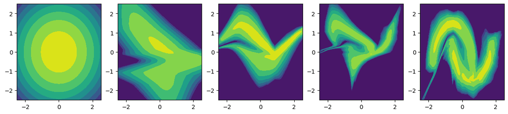

```python
def part_model(model, num_coupling_layers):
    """Create a new model that uses only the first affine coupling layers."""
    layers = []
    for layer in model.flow.layers:
        if isinstance(layer, AffineCoupling):
            if num_coupling_layers > 0:
                num_coupling_layers -= 1
                layers.append(layer)
        else:
            layers.append(layer)
    return NormalizingFlow(model.base_distribution, *layers)

def plot_model_steps(model, steps):
    plt.figure(figsize=(3*steps, 3))
    for i in range(steps):
        plt.subplot(1, steps, i + 1)
        plot_log_prob(part_model(model,i), colorbar=False)

plot_model_steps(model, 5)
```

**10.5 h Add comment(h) Train the model again, and compare the above plot between the two runs. Are the models similar? (1 point)**

```
2.3751628021240236
2.100171496047974
2.034372050743103
2.0063447729873656
1.963982985420227
1.9471244166183472
1.9361688213729857
1.9262957947158814
1.9186967929077148
1.9134771001434325
1.9087212018966675
1.9037913102340698
1.9005159047317506
1.8977483305358887
1.8955675413894653
1.8939009157180786
1.892034122200012
1.8906412353515625
1.8892582626724244
1.888095678100586
train loss 1.888
```

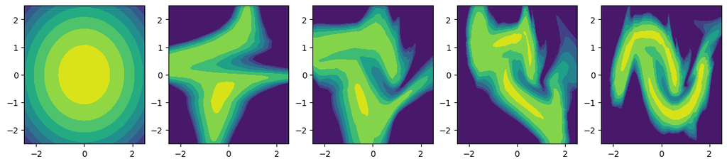

```python
### BEGIN ANSWER
model2 = make_model(4, 2, 16)
train(model2, moon_data_loader, num_epochs=20)
plot_model_steps(model2, 5)
### END ANSWER
```

Answer:

Training again can produce a model with very different intermediate steps.

It looks like the model is sensitive to the initialization, and different initializations can give different solutions.

*Grading:*

- 1 point for a correct answer.

## 10.6 Discussion (3 points)

**10.6 a Add comment(a) How does the normalizing flow model differ from the GAN trained in assignment 9.7b? (1 point)**

Compare to both the generator and discriminator plots.

Answer:

The GAN produces samples that do not match the distribution as closely.

The discriminator from the GAN is very different from the log probability learned by the normalizing flow. The latter matches the true distribution much more closely.

*Grading:*

- 1 point for a good comparison. It should mention both generator/samples as well as discriminator.

**10.6 b Add comment(b) We have used a standard normal distribution as the base distribution. Another choice is a uniform distribution. What is a potential problem with using a uniform distribution? (1 point)**

Answer:

The uniform distribution has only finite support, so it is possible that the inverse flow function produces a point outside the uniform base distribution. Then this has likelihood 0, so log likelihood -∞, and zero gradient.

*Grading:*

- 1 point for the correct answer.

**10.6 c Add comment(c) According to the manifold hypothisis, real data often lies on a low dimensional manifold in a high dimensional space. Can you use this idea in a normalizing flow model, by having a low dimensional latent space? Explain your answer. (1 point)**

Answer:

No. A normalizing flow model is built from invertible transformations, so the input dimension and output dimension must be the same.

*Grading:*

- 1 point for the correct answer with an explanation.
- 0.5 points if no explanation

## The end

Well done! Please double check the instructions at the top before you submit your results.

*This assignment has 29 points.* Version 36dc7f6 / 2024-11-21

## Score form

Something didn't work. Save the following list of scores in a text file and upload to Brightspace:

Download the scores as a text file